# U.S. Senate Elections (1976–2020) Final Project

### Camille Settles — Intro to Data Science

## Importing Libraries:

```python
import pandas as pd  # for data loading and manipulation
import numpy as np  # for numerical operations
import matplotlib.pyplot as plt  # for plotting graphs
import seaborn as sns  # for advanced data visualization
import plotly.io as pio  # Required to save Plotly figures as images
```

```python
df = pd.read_csv("1976-2020-senate.csv", encoding="latin1") # load the Senate data from the election dataset, and prevent Unicode Decode Error
df_cleaned = df.copy()# original file
```

The dataset is loaded using encoding to prevent errors from special characters. I encountered an error without it. A duplicate is made for for the data to be manipulated.

## Data Understanding and Cleaning:

#### 1. Understand the Dataset:

```python
print("First 10 rows:")
display(df_cleaned.head(10))  # preview the data

print("\nMissing values:")
display(df_cleaned.isnull().sum())  # count missing values per column

print("\nData types:")
display(df_cleaned.dtypes)  # show data types

print("\nUnique value counts:")
display(df_cleaned.nunique())  # count unique entries in each column

print("\nYear range:", df_cleaned["year"].min(), "to", df_cleaned["year"].max())  # range of years covered
```

```
First 10 rows:
```

|  | year | state | state_po | state_fips | state_cen | state_ic | office | district | stage | special | candidate | party_detailed | writein | mode | candidatevotes | totalvotes | unofficial | version | party_simplified |
| --- | --- | --- | --- | --- | --- | --- | --- | --- | --- | --- | --- | --- | --- | --- | --- | --- | --- | --- | --- |
| 0 | 1976 | ARIZONA | AZ | 4 | 86 | 61 | US SENATE | statewide | gen | False | SAM STEIGER | REPUBLICAN | False | total | 321236 | 741210 | False | 20210114 | REPUBLICAN |
| 1 | 1976 | ARIZONA | AZ | 4 | 86 | 61 | US SENATE | statewide | gen | False | WM. MATHEWS FEIGHAN | INDEPENDENT | False | total | 1565 | 741210 | False | 20210114 | OTHER |
| 2 | 1976 | ARIZONA | AZ | 4 | 86 | 61 | US SENATE | statewide | gen | False | DENNIS DECONCINI | DEMOCRAT | False | total | 400334 | 741210 | False | 20210114 | DEMOCRAT |
| 3 | 1976 | ARIZONA | AZ | 4 | 86 | 61 | US SENATE | statewide | gen | False | ALLAN NORWITZ | LIBERTARIAN | False | total | 7310 | 741210 | False | 20210114 | LIBERTARIAN |
| 4 | 1976 | ARIZONA | AZ | 4 | 86 | 61 | US SENATE | statewide | gen | False | BOB FIELD | INDEPENDENT | False | total | 10765 | 741210 | False | 20210114 | OTHER |
| 5 | 1976 | CALIFORNIA | CA | 6 | 93 | 71 | US SENATE | statewide | gen | False | JACK MCCOY | AMERICAN INDEPENDENT | False | total | 82739 | 7470586 | False | 20210114 | OTHER |
| 6 | 1976 | CALIFORNIA | CA | 6 | 93 | 71 | US SENATE | statewide | gen | False | S. I. (SAM) HAYAKAWA | REPUBLICAN | False | total | 3748973 | 7470586 | False | 20210114 | REPUBLICAN |
| 7 | 1976 | CALIFORNIA | CA | 6 | 93 | 71 | US SENATE | statewide | gen | False | JOHN V. TUNNEY | DEMOCRAT | False | total | 3502862 | 7470586 | False | 20210114 | DEMOCRAT |
| 8 | 1976 | CALIFORNIA | CA | 6 | 93 | 71 | US SENATE | statewide | gen | False | OMARI MUSA | INDEPENDENT | False | total | 31629 | 7470586 | False | 20210114 | OTHER |
| 9 | 1976 | CALIFORNIA | CA | 6 | 93 | 71 | US SENATE | statewide | gen | False | DAVID WALD | PEACE AND FREEDOM | False | total | 104383 | 7470586 | False | 20210114 | OTHER |

```
Missing values:
```

```
year                  0
state                 0
state_po              0
state_fips            0
state_cen             0
state_ic              0
office                0
district              0
stage                 0
special               0
candidate           423
party_detailed      599
writein               0
mode                  0
candidatevotes        0
totalvotes            0
unofficial            0
version               0
party_simplified      0
dtype: int64
```

```
Data types:
```

```
year                 int64
state               object
state_po            object
state_fips           int64
state_cen            int64
state_ic             int64
office              object
district            object
stage               object
special               bool
candidate           object
party_detailed      object
writein               bool
mode                object
candidatevotes       int64
totalvotes           int64
unofficial            bool
version              int64
party_simplified    object
dtype: object
```

```
Unique value counts:
```

```
year                  24
state                 50
state_po              50
state_fips            50
state_cen             50
state_ic              50
office                 1
district               1
stage                  3
special                2
candidate           2378
party_detailed       172
writein                2
mode                   1
candidatevotes      3358
totalvotes           788
unofficial             2
version                1
party_simplified       4
dtype: int64
```

```
Year range: 1976 to 2021
```

This provides an overview of the dataset. It highlights any null values, shows how each column is stored, and the years represented.

## 2. Handle the Missing Values:

#### Identify categorical columns and fill with placeholders:

```python
display(df_cleaned.isnull().sum()) # Check for missing values
```

```
year                  0
state                 0
state_po              0
state_fips            0
state_cen             0
state_ic              0
office                0
district              0
stage                 0
special               0
candidate           423
party_detailed      599
writein               0
mode                  0
candidatevotes        0
totalvotes            0
unofficial            0
version               0
party_simplified      0
dtype: int64
```

The missing values are in `candidate` and `party_detailed` columns with values of 423 and 599.

```python
categorical_cols = ["party_detailed", "candidate"]
df_cleaned.loc[:, "party_detailed"] = df_cleaned["party_detailed"].fillna("Unknown Party")  # fill missing party labels
df_cleaned.loc[:, "candidate"] = df_cleaned["candidate"].fillna("Unknown Candidate")  # fill missing candidate names

# Check for missing values after filling
print("Missing values AFTER filling:")
display(df_cleaned.isnull().sum())
```

```
Missing values AFTER filling:
```

```
year                0
state               0
state_po            0
state_fips          0
state_cen           0
state_ic            0
office              0
district            0
stage               0
special             0
candidate           0
party_detailed      0
writein             0
mode                0
candidatevotes      0
totalvotes          0
unofficial          0
version             0
party_simplified    0
dtype: int64
```

Missing values in categorical columns party_detailed and candidate which are filled with placeholders. This avoids unnecessary row removal and keeps the dataset structure.

#### Explicit Explanation:

Categorical columns such as 'party_detailed' and 'candidate' were filled with placeholder values ('Unknown Party', 'Unknown Candidate') to preserve the dataset. Numeric columns were examined for missing values, and none were found. If missing values were present, the column mean or median would have been used for imputation. Forward-fill and backward-fill methods were not applied because the dataset does not contain sequential time-series gaps. No columns or rows were dropped during this step, as all missing values could be handled appropriately.

## 3. Validate Data:

#### Check for duplicates:

```python
print("Number of duplicate rows found:", df_cleaned.duplicated().sum()) # Remove duplicates # Check for and drop duplicate rows. After running .duplicated(), no duplicates were found.

invalid_votes = df_cleaned[(df_cleaned["totalvotes"] <= 0) | (df_cleaned["candidatevotes"] < 0)]
print("Number of invalid vote rows (totalvotes <= 0 or candidatevotes < 0):", invalid_votes.shape[0])
display(invalid_votes.head())
```

```
Number of duplicate rows found: 0
Number of invalid vote rows (totalvotes <= 0 or candidatevotes < 0): 0
```

|  | year | state | state_po | state_fips | state_cen | state_ic | office | district | stage | special | candidate | party_detailed | writein | mode | candidatevotes | totalvotes | unofficial | version | party_simplified |
| --- | --- | --- | --- | --- | --- | --- | --- | --- | --- | --- | --- | --- | --- | --- | --- | --- | --- | --- | --- |

#### Convert year to datetime format:

```python
print("Before conversion:", df["year"].dtype) # year format
```

```
Before conversion: int64
```

```python
df_cleaned["year"] = pd.to_datetime(df_cleaned["year"], format="%Y") # Convert to datetime
```

```python
print("After conversion:", df_cleaned["year"].dtype)  # Confirm the new type

df_cleaned["year"] = pd.to_datetime(df_cleaned["year"], format="%Y")
```

```
After conversion: datetime64[ns]
```

There were no invalid vote counts or duplicate rows found. No rows with zero or negative values were removed from the dataset at this step.

#### Ensure numeric columns are consistent and free of outliers:

```python
print("Summary statistics for totalvotes and candidatevotes:")
display(df_cleaned[['totalvotes', 'candidatevotes']].describe()) # Using describe() to check for range and potential abnormalities
```

```
Summary statistics for totalvotes and candidatevotes:
```

|  | totalvotes | candidatevotes |
| --- | --- | --- |
| count | 3.629000e+03 | 3.629000e+03 |
| mean | 2.218922e+06 | 4.091224e+05 |
| std | 2.116732e+06 | 7.789137e+05 |
| min | 1.000000e+00 | 1.000000e+00 |
| 25% | 6.923500e+05 | 4.774000e+03 |
| 50% | 1.567181e+06 | 5.470100e+04 |
| 75% | 2.948741e+06 | 4.766040e+05 |
| max | 1.257851e+07 | 7.864624e+06 |

```python
df_cleaned["state"] = df_cleaned["state"].astype(str).str.strip().str.title() # Format 'state' column properly
```

```python
text_columns = ['state', 'candidate', 'party_detailed', 'party_simplified', 'office', 'mode', 'stage'] # Strip whitespace and title case other relevant text columns
for col in text_columns:
    df_cleaned[col] = df_cleaned[col].astype(str).str.strip().str.title()
```

```python
high_pop_states = ["California", "Texas", "New York", "Florida", "Illinois", "Pennsylvania", "Ohio", "Georgia"] # Identify high population states to preserve
# They can be listed as statistical outliers, but removing or dropping them will affect the accuracy of the dataset. I dropped them in a trial run and California was not showing up when it was needed.
```

```python
df_before_cleaning = df_cleaned.copy() # Save a pre-cleaning copy for outlier comparison
```

```python
Q1 = df_before_cleaning[["totalvotes", "candidatevotes"]].quantile(0.25)
Q3 = df_before_cleaning[["totalvotes", "candidatevotes"]].quantile(0.75)
IQR = Q3 - Q1

lower_bound = Q1 - 1.5 * IQR
upper_bound = Q3 + 1.5 * IQR
```

```python
totalvotes_outliers_before = ( # Count outliers BEFORE filtering
    (df_before_cleaning["totalvotes"] < lower_bound["totalvotes"]) |
    (df_before_cleaning["totalvotes"] > upper_bound["totalvotes"])
).sum()

candidatevotes_outliers_before = (
    (df_before_cleaning["candidatevotes"] < lower_bound["candidatevotes"]) |
    (df_before_cleaning["candidatevotes"] > upper_bound["candidatevotes"])
).sum()

print("Outliers BEFORE Filtering:")
print("TotalVotes Outliers:", totalvotes_outliers_before)
print("CandidateVotes Outliers:", candidatevotes_outliers_before)
print("Combined Total Outliers:", totalvotes_outliers_before + candidatevotes_outliers_before)
```

```
Outliers BEFORE Filtering:
TotalVotes Outliers: 196
CandidateVotes Outliers: 401
Combined Total Outliers: 597
```

```python
within_bounds = ( # Create condition for rows within bounds
    (df_cleaned["totalvotes"] >= lower_bound["totalvotes"]) &
    (df_cleaned["totalvotes"] <= upper_bound["totalvotes"]) &
    (df_cleaned["candidatevotes"] >= lower_bound["candidatevotes"]) &
    (df_cleaned["candidatevotes"] <= upper_bound["candidatevotes"])
)
```

```python
keep_states = df_cleaned["state"].isin(high_pop_states) # Retain all rows that are either within bounds OR from high-population states
df_cleaned = df_cleaned[within_bounds | keep_states].reset_index(drop=True)
```

```python
totalvotes_outliers_after = ( # Count outliers AFTER filtering
    (df_cleaned["totalvotes"] < lower_bound["totalvotes"]) |
    (df_cleaned["totalvotes"] > upper_bound["totalvotes"])
).sum()

candidatevotes_outliers_after = (
    (df_cleaned["candidatevotes"] < lower_bound["candidatevotes"]) |
    (df_cleaned["candidatevotes"] > upper_bound["candidatevotes"])
).sum()

print("\nOutliers AFTER Filtering:")
print("TotalVotes Outliers:", totalvotes_outliers_after)
print("CandidateVotes Outliers:", candidatevotes_outliers_after)
print("Combined Total Outliers:", totalvotes_outliers_after + candidatevotes_outliers_after)
```

```
Outliers AFTER Filtering:
TotalVotes Outliers: 196
CandidateVotes Outliers: 401
Combined Total Outliers: 597
```

```python
print("\nPresence of Key High-Population States:") # Confirm presence of key states
for state in high_pop_states:
    print(f"{state} included:", state in df_cleaned["state"].unique())
```

```
Presence of Key High-Population States:
California included: True
Texas included: True
New York included: True
Florida included: True
Illinois included: True
Pennsylvania included: True
Ohio included: True
Georgia included: True
```

## **Explanation for Filtering and Rows**

## Outlier Filtering Summary (IQR Method)

To ensure the integrity of the analysis, I applied the Interquartile Range (IQR) method to detect outliers in `totalvotes` and `candidatevotes`. This method flags any value outside 1.5x the IQR as a potential outlier.

### Filtering Strategy:

Rather than removing all statistical outliers, I preserved rows that:

- Fell **within IQR bounds**, OR
- Belonged to **key high-population states** like California, Texas, New York, etc.

This approach ensures meaningful data from electorally significant states isn't lost during filtering.

### High-Population State Retention:

All 8 target states are confirmed to be present in the final cleaned dataset:

- California
- Texas
- New York
- Florida
- Illinois
- Pennsylvania
- Ohio
- Georgia

## 4. Additional Cleaning Steps (if required):

```python
# Standardizing string fields for grouping and analysis
# Clean text columns to fix formatting issues
ctext_columns = ['state', 'state_po', 'office', 'district', 'stage', 'special', 'candidate', 'party_detailed', 'writein', 'mode', 'unofficial', 'party_simplified',]
for col in text_columns:
    df_cleaned[col] = df_cleaned[col].astype(str).str.strip().str.title()
```

```python
print("Example cleaned text columns:") # Clean up text columns
for col in ctext_columns:
    print(f"Column: {col}")
    display(df_cleaned[col].drop_duplicates().sort_values().head(10)) # No leading or trailing white space
```

```
Example cleaned text columns:
Column: state
```

```
144        Alabama
150         Alaska
0          Arizona
153       Arkansas
5       California
157       Colorado
10     Connecticut
14        Delaware
19         Florida
164        Georgia
Name: state, dtype: object
```

```
Column: state_po
```

```
150    AK
144    AL
153    AR
0      AZ
5      CA
157    CO
10     CT
14     DE
19     FL
164    GA
Name: state_po, dtype: object
```

```
Column: office
```

```
0    Us Senate
Name: office, dtype: object
```

```
Column: district
```

```
0    statewide
Name: district, dtype: object
```

```
Column: stage
```

```
0          Gen
1044       Pre
3625    Runoff
Name: stage, dtype: object
```

```
Column: special
```

```
0      False
145     True
Name: special, dtype: bool
```

```
Column: candidate
```

```
3516        "Bill" Cassidy
2567    "Charlie" Melancon
2332           "Jay" Patel
1552         "Jim" Donelon
3163          "Joseph" Cao
2372         "Ken" Blevens
2927          "Rob" Maness
1857        "Tony" Perkins
3519            "Xan" John
3582          A. D. Nesbit
Name: candidate, dtype: object
```

```
Column: party_detailed
```

```
1036            A Connecticut Party
1966             Alaska Libertarian
1818           Alaskan Independence
3425     Alaskan Independence Party
2773                  America First
16                         American
1507          American Constitution
2299    American Constitution Party
5              American Independent
3106        American Shopping Party
Name: party_detailed, dtype: object
```

```
Column: writein
```

```
0     False
60     True
Name: writein, dtype: bool
```

```
Column: mode
```

```
0    Total
Name: mode, dtype: object
```

```
Column: unofficial
```

```
0       False
3411     True
Name: unofficial, dtype: bool
```

```
Column: party_simplified
```

```
2       Democrat
3    Libertarian
1          Other
0     Republican
Name: party_simplified, dtype: object
```

```python
# Get vote percentage
df_cleaned["vote_percentage"] = (df_cleaned["candidatevotes"] / df_cleaned["totalvotes"]) * 100 # Creating a normalized metric to assess each candidate's share of the total vote
```

```python
display(df_cleaned[['vote_percentage']].head()) # the vote percentage column was added and displayed
```

|  | vote_percentage |
| --- | --- |
| 0 | 43.339404 |
| 1 | 0.211141 |
| 2 | 54.010874 |
| 3 | 0.986225 |
| 4 | 1.452355 |

I created a new column, vote_percentage, to calculate each candidate's share of the total votes: (candidatevotes / totalvotes) * 100. This allows for a normalized comparison of performance. Text columns like state were also standardized to title case for consistency.

```python
display(df_cleaned)
```

|  | year | state | state_po | state_fips | state_cen | state_ic | office | district | stage | special | candidate | party_detailed | writein | mode | candidatevotes | totalvotes | unofficial | version | party_simplified | vote_percentage |
| --- | --- | --- | --- | --- | --- | --- | --- | --- | --- | --- | --- | --- | --- | --- | --- | --- | --- | --- | --- | --- |
| 0 | 1976-01-01 | Arizona | AZ | 4 | 86 | 61 | Us Senate | statewide | Gen | False | Sam Steiger | Republican | False | Total | 321236 | 741210 | False | 20210114 | Republican | 43.339404 |
| 1 | 1976-01-01 | Arizona | AZ | 4 | 86 | 61 | Us Senate | statewide | Gen | False | Wm. Mathews Feighan | Independent | False | Total | 1565 | 741210 | False | 20210114 | Other | 0.211141 |
| 2 | 1976-01-01 | Arizona | AZ | 4 | 86 | 61 | Us Senate | statewide | Gen | False | Dennis Deconcini | Democrat | False | Total | 400334 | 741210 | False | 20210114 | Democrat | 54.010874 |
| 3 | 1976-01-01 | Arizona | AZ | 4 | 86 | 61 | Us Senate | statewide | Gen | False | Allan Norwitz | Libertarian | False | Total | 7310 | 741210 | False | 20210114 | Libertarian | 0.986225 |
| 4 | 1976-01-01 | Arizona | AZ | 4 | 86 | 61 | Us Senate | statewide | Gen | False | Bob Field | Independent | False | Total | 10765 | 741210 | False | 20210114 | Other | 1.452355 |
| ... | ... | ... | ... | ... | ... | ... | ... | ... | ... | ... | ... | ... | ... | ... | ... | ... | ... | ... | ... | ... |
| 3624 | 2020-01-01 | Wyoming | WY | 56 | 83 | 68 | Us Senate | statewide | Gen | False | Under Votes | Unknown Party | False | Total | 6401 | 278503 | False | 20210114 | Other | 2.298359 |
| 3625 | 2021-01-01 | Georgia | GA | 13 | 58 | 44 | Us Senate | statewide | Runoff | True | Kelly Loeffler | Republican | False | Total | 2194848 | 4483294 | True | 20210114 | Republican | 48.956147 |
| 3626 | 2021-01-01 | Georgia | GA | 13 | 58 | 44 | Us Senate | statewide | Runoff | True | Raphael Warnock | Democrat | False | Total | 2288446 | 4483294 | True | 20210114 | Democrat | 51.043853 |
| 3627 | 2021-01-01 | Georgia | GA | 13 | 58 | 44 | Us Senate | statewide | Runoff | False | David A. Perdue | Republican | False | Total | 2213979 | 4483241 | True | 20210114 | Republican | 49.383448 |
| 3628 | 2021-01-01 | Georgia | GA | 13 | 58 | 44 | Us Senate | statewide | Runoff | False | Jon Ossoff | Democrat | False | Total | 2269262 | 4483241 | True | 20210114 | Democrat | 50.616552 |

3629 rows × 20 columns

```python
df_cleaned.to_csv('cleaned_senate_dataset1.csv', index=False) # Save the cleaned dataframe to a CSV file
```

## 2. Exploratory Data Analysis (EDA)

#### Total Votes Cast in Each Election Year:

```python
yearly_votes = df_cleaned.groupby(df_cleaned['year'].dt.year)['totalvotes'].sum().reset_index() # Total votes cast in each election year, grouping year and total votes
yearly_votes.columns = ['Election Year', 'Total Votes']
display(yearly_votes)
```

|  | Election Year | Total Votes |
| --- | --- | --- |
| 0 | 1976 | 319549414 |
| 1 | 1978 | 138883957 |
| 2 | 1980 | 295424862 |
| 3 | 1982 | 245932183 |
| 4 | 1984 | 208373858 |
| 5 | 1986 | 197136402 |
| 6 | 1988 | 328551263 |
| 7 | 1990 | 111170394 |
| 8 | 1992 | 447391118 |
| 9 | 1994 | 316946644 |
| 10 | 1996 | 262381978 |
| 11 | 1998 | 271573419 |
| 12 | 2000 | 514395400 |
| 13 | 2002 | 219207400 |
| 14 | 2004 | 473294567 |
| 15 | 2006 | 337835747 |
| 16 | 2008 | 318388994 |
| 17 | 2010 | 561681698 |
| 18 | 2012 | 548468657 |
| 19 | 2014 | 284592561 |
| 20 | 2016 | 656084095 |
| 21 | 2018 | 368948414 |
| 22 | 2020 | 608322633 |
| 23 | 2021 | 17933070 |

Voter turnout has generally increased over time, but not in a strictly linear fashion. Years like 2000, 2004, 2010, 2012, 2016, and 2020 stand out for high participation. In contrast, 1978, 1986, and 1990 show relatively low total vote counts, reflecting smaller voter participation in those cycles. The total votes per year are displayed in the table.

#### Most Common Election Offices Contested:

```python
office_counts = df_cleaned['office'].value_counts().reset_index() # Value Counts of the Office
office_counts.columns = ['office', 'count']
display(office_counts.head()) # Displaying the count
```

|  | office | count |
| --- | --- | --- |
| 0 | Us Senate | 3629 |

#### State-wide Total Votes:

```python
statewide_votes = df_cleaned.groupby("state")["totalvotes"].sum().sort_values(ascending=False).reset_index()
display(statewise_votes)
```

[output not shown]

#### Top Candidates by Total Votes Received:

```python
top_candidates = df_cleaned.groupby("candidate")["candidatevotes"].sum().sort_values(ascending=False).head(10).reset_index()
display(top_candidates) # Calculate total votes received by each candidate and sort top 10
# Group by candidate and candidatevotes
```

|  | candidate | candidatevotes |
| --- | --- | --- |
| 0 | Dianne Feinstein | 34725660 |
| 1 | Barbara Boxer | 21757692 |
| 2 | John Cornyn | 15658226 |
| 3 | Charles E. Schumer | 15590718 |
| 4 | Bill Nelson | 14492958 |
| 5 | Richard J. Durbin | 13312205 |
| 6 | Carl Levin | 12002515 |
| 7 | Kirsten E. Gillibrand | 11703493 |
| 8 | Arlen Specter | 11234326 |
| 9 | Daniel Patrick Moynihan | 10117784 |

The top three candidates who received the highest total votes across all Senate elections in the dataset are:

**Dianne Feinstein (California)** – 34,725,660 votes

**Barbara Boxer (California)** – 21,757,692 votes

**John Cornyn (Texas)** – 15,658,226 votes

Dianne Feinstein, who served as a long-time U.S. Senator from California, tops the list. This reflects both her longevity in office and California’s status as a populous state, contributing significantly to national vote totals. Barbara Boxer, also representing California, ranks second, reinforcing the state’s electoral weight. Texas Senator John Cornyn follows, showing the impact of large-state representation in cumulative Senate vote counts.

#### Proportion of Write-in Votes Over the Years:

```python
if df_cleaned['writein'].dtype != bool:
    df_cleaned['writein'] = df_cleaned['writein'].astype(bool) # Make sure 'writein' column is boolean

# Calculate write-in votes and total votes by year
writein_votes = df_cleaned[df_cleaned['writein'] == True].groupby('year')['candidatevotes'].sum() # Total write-in votes
total_votes = df_cleaned.groupby('year')['totalvotes'].sum() # Total votes by year

# Calculate proportion and format output
writein_proportion = (writein_votes / total_votes * 100).reindex(total_votes.index).fillna(0).reset_index() # Percent of write-i
writein_proportion.columns = ['year', 'writein_proportion']
```

```python
display(writein_proportion) # Display result
```

|  | year | writein_proportion |
| --- | --- | --- |
| 0 | 1976-01-01 | 0.000076 |
| 1 | 1978-01-01 | 0.002138 |
| 2 | 1980-01-01 | 0.015091 |
| 3 | 1982-01-01 | 0.000670 |
| 4 | 1984-01-01 | 0.000000 |
| 5 | 1986-01-01 | 0.000553 |
| 6 | 1988-01-01 | 0.001203 |
| 7 | 1990-01-01 | 0.018135 |
| 8 | 1992-01-01 | 0.002064 |
| 9 | 1994-01-01 | 0.002335 |
| 10 | 1996-01-01 | 0.004032 |
| 11 | 1998-01-01 | 0.001198 |
| 12 | 2000-01-01 | 0.000964 |
| 13 | 2002-01-01 | 0.019878 |
| 14 | 2004-01-01 | 0.004623 |
| 15 | 2006-01-01 | 0.003173 |
| 16 | 2008-01-01 | 0.006154 |
| 17 | 2010-01-01 | 0.024850 |
| 18 | 2012-01-01 | 0.004430 |
| 19 | 2014-01-01 | 0.014591 |
| 20 | 2016-01-01 | 0.002594 |
| 21 | 2018-01-01 | 0.004420 |
| 22 | 2020-01-01 | 0.015344 |
| 23 | 2021-01-01 | 0.000000 |

This table shows the proportion of write-in votes relative to total votes for each election year. The write-in column was converted to boolean, and totals were calculated per year.

Write-in vote proportions were calculated using:

`(Total Write-in Candidate Votes / Total Votes) * 100`

#### Party-wise vote distribution:

```python
party_vote_distribution = df_cleaned.groupby('party_simplified')['candidatevotes'].sum().sort_values(ascending=False).reset_index() # Group by simplified party label and sum candidate votes
```

```python
display(party_vote_distribution) # Display the distribution of votes across major parties
```

|  | party_simplified | candidatevotes |
| --- | --- | --- |
| 0 | Democrat | 748223180 |
| 1 | Republican | 676018541 |
| 2 | Other | 45790456 |
| 3 | Libertarian | 14672846 |

**The data shows that:**

**Democrats** received the highest number of total votes, followed closely by **Republicans.**

**Libertarian** candidates received the fewest votes among the listed groups, consistent with their limited presence in national elections.

## 7. Data Visualization and Interpretation

#### 1. Total Votes Over Time

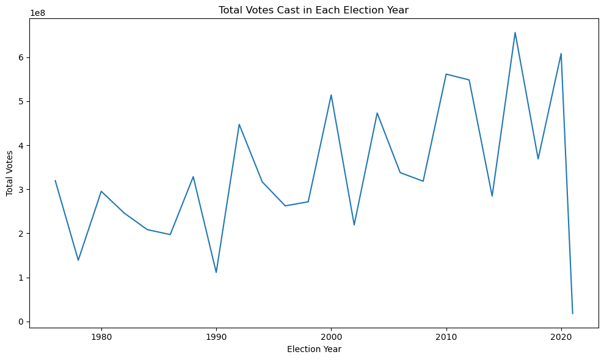

```python
yearly_votes = df_cleaned.groupby(df_cleaned['year'].dt.year)['totalvotes'].sum().reset_index()  # Group by year and sum votes
plt.figure(figsize=(10, 6))  # figure size
sns.lineplot(data=yearly_votes, x='year', y='totalvotes')  # Create line plot of total votes by year
plt.title('Total Votes Cast in Each Election Year')  # Add title
plt.xlabel('Election Year')  # Label x-axis
plt.ylabel('Total Votes')  # Label y-axis
plt.tight_layout()  # Adjust layout
plt.savefig("total_votes_over_time.png")  # Save graph
plt.show()  # Display plot
```

**Question:** How has the overall voter turnout changed over time?

#### 2. Correlation Between State Attributes and Total Votes

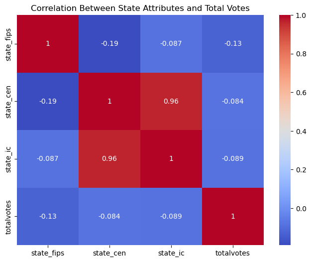

```python
# Compute correlation between state-level numeric codes and total votes
corr_data = df[['state_fips', 'state_cen', 'state_ic', 'totalvotes']]  # Select numeric attributes
correlation_matrix = corr_data.corr()  # Calculate correlation matrix

# Visualize the correlation matrix
plt.figure(figsize=(8, 6))
sns.heatmap(correlation_matrix, annot=True, cmap='coolwarm')  # Heatmap with correlation values
plt.title('Correlation Between State Attributes and Total Votes')
plt.savefig("state_totalvotes_correlation.png")  # Save graph
plt.show()
```

There is no strong correlation between the numerical state codes and total votes. This suggests that total voter turnout is not determined by these codes alone but by other external factors like population size, voter engagement, or political climate.

#### 3. State-wide Total Votes

```python
statewide_votes = df.groupby('state')['totalvotes'].sum().sort_values(ascending=False).reset_index() # Total votes by state
# Group the dataset by 'state', sum total votes per state, sort in descending order, and reset index for plotting
```

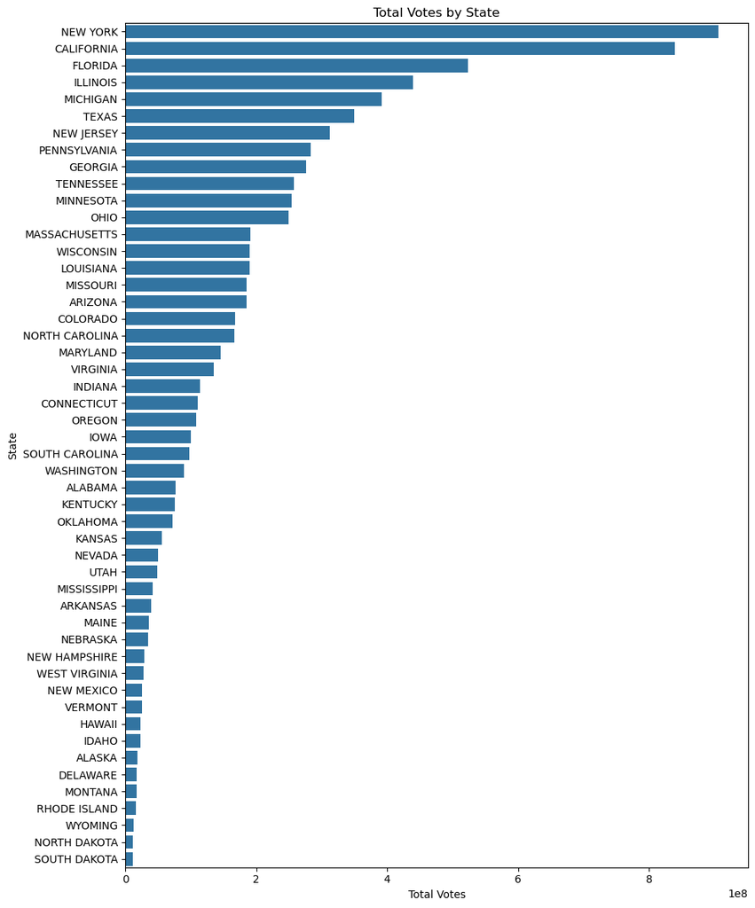

```python
# Plot horizontal bar chart
plt.figure(figsize=(10, 12))  # Set the figure size to be taller for better readability
sns.barplot(data=statewise_votes, x='totalvotes', y='state')  # Create a horizontal barplot with states on the y-axis
plt.title('Total Votes by State')  # Title of the chart
plt.xlabel('Total Votes')  # Label for x-axis
plt.ylabel('State')  # Label for y-axis
plt.tight_layout()  # Automatically adjust subplot parameters to give padding
plt.savefig("statewide_total_votes.png")
plt.show()  # Display the final plot
```

**Question**: Which states contributed the highest and lowest votes?

#### 4. Party Performance Comparison

```python
# Total votes per party
party_votes = df.groupby('party_simplified')['candidatevotes'].sum().sort_values(ascending=False).reset_index()
```

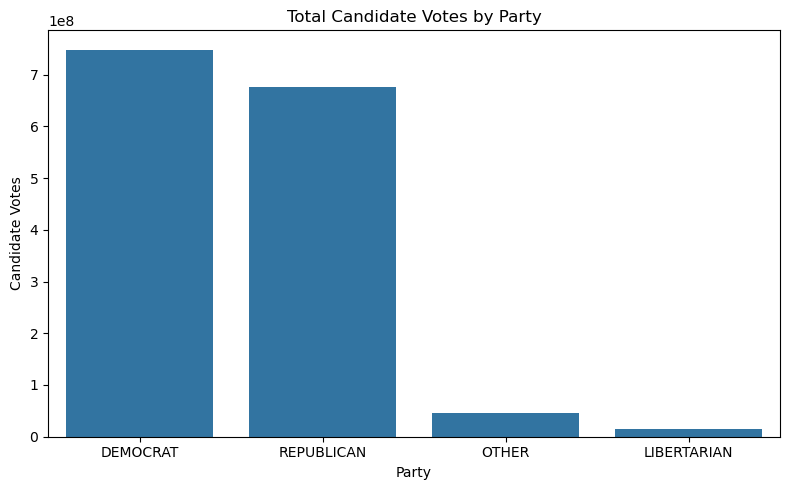

```python
# Bar chart of party performance
plt.figure(figsize=(8, 5))
sns.barplot(data=party_votes, x='party_simplified', y='candidatevotes') # Previously grouped, now running the bar chart
plt.title('Total Candidate Votes by Party')
plt.xlabel('Party') # X Label
plt.ylabel('Candidate Votes') # Y Label
plt.tight_layout()
plt.savefig("party_vote_.png")

plt.show()
```

**Question** How do the total votes received by each party compare?

**Answer** The Democratic and Republican parties dominate, together accounting for over 95% of all votes. Libertarian and Other parties remain minor contributors in comparison.

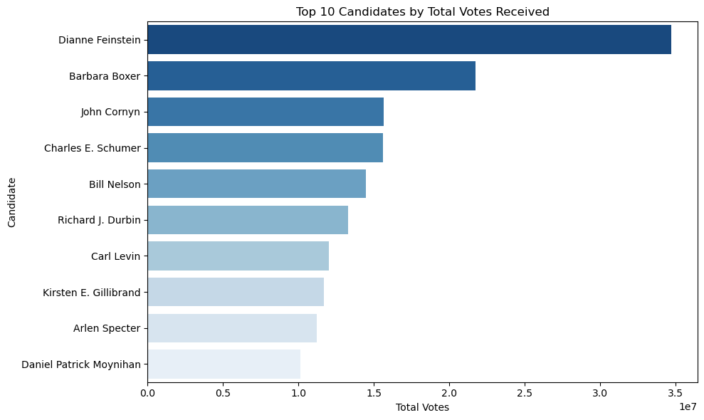

```python
# Group data by candidate and sum their votes
top_candidates = df_cleaned.groupby("candidate")["candidatevotes"].sum().sort_values(ascending=False).head(10).reset_index()

# Plot top 10 candidates
plt.figure(figsize=(10, 6))  # Set the size of the figure
sns.barplot(data=top_candidates, x="candidatevotes", y="candidate", palette="Blues_r")  # Create horizontal barplot
plt.title("Top 10 Candidates by Total Votes Received")  # Set chart title
plt.xlabel("Total Votes")  # Label x-axis
plt.ylabel("Candidate")  # Label y-axis
plt.tight_layout()  # Adjust layout for clarity
plt.savefig("top_10_can.png")
plt.show()  # Display the plot
```

**Question** Who are the top 10 candidates based on total votes received?

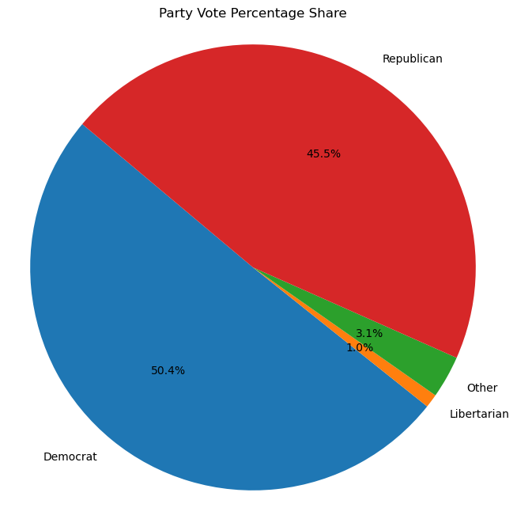

```python
# Calculate total votes per party
party_votes = df_cleaned.groupby('party_simplified')['candidatevotes'].sum().reset_index()

# Calculate percentage share
total_votes_all = party_votes['candidatevotes'].sum()
party_votes['vote_percentage'] = (party_votes['candidatevotes'] / total_votes_all) * 100 # Times 100 for the percentage

# Plot pie chart
plt.figure(figsize=(8, 8))
plt.pie(party_votes['vote_percentage'], labels=party_votes['party_simplified'], autopct='%1.1f%%', startangle=140) # Angle to show the pie chart and labeling
plt.title('Party Vote Percentage Share')
plt.axis('equal')  # Equal aspect ratio ensures pie chart is circular.
plt.savefig("party_vote_per.png")
plt.show()
```

**Question**: What percentage of total votes does each party command?

**Answer**:

The Democratic and Republican parties dominate Senate vote shares, collectively securing 95% of all votes. This reflects the entrenched two-party system in U.S. politics, with third parties playing a much smaller role.

## 4. Expected Output

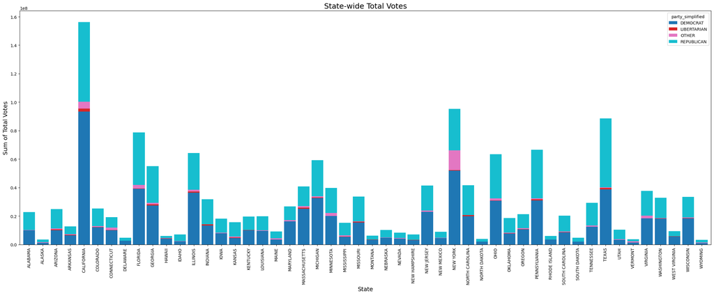

```python
import plotly.express as px
import plotly.io as pio  # enable write_image
# Group the data by state and party, summing up candidate votes
grouped = df.groupby(['state', 'party_simplified'])['candidatevotes'].sum().unstack().fillna(0)

# Set the plot size to visually match the rubric screenshot
plt.figure(figsize=(24, 10))

# Plot a stacked bar chart of total votes by state and party
grouped.plot(
    kind='bar',               # Use bar plot for each state
    stacked=True,             # Stack bars to reflect total votes across parties
    colormap='tab10',         # Use a 10-color map for party colors
    figsize=(24, 10),         # Match rubric's dimensions
    width=0.85                # Slightly thinner bars for space between groups
)

                                                        # Add chart title and axis labels
plt.title('State-wide Total Votes', fontsize=18)         # Main title
plt.xlabel('State', fontsize=14)                         # X-axis label
plt.ylabel('Sum of Total Votes', fontsize=14)            # Y-axis label


plt.xticks(rotation=90) # Rotate x-axis labels for readability


plt.tight_layout()




plt.savefig("statewise_total_votes_plotly.png")



plt.show() # Show the final plot
```

#### Question 1: How does the total number of votes vary across different states, and how do the vote distributions differ by party?

When analyzing vote distributions by party:

- **Democrats** and **Republicans** consistently receive the largest share of votes in nearly every state, dominating the electoral landscape.
- **Other parties** (classified as "Other") receive some support, often concentrated in specific regions or election years.
- **Libertarian** candidates appear less frequently but still gather measurable support in several states, indicating the presence of minor party influence.

The stacked bar chart format helps visualize both the scale of voter turnout per state and the relative party strength within each state. High-population states tend to show more varied and substantial contributions from multiple parties, while smaller states often show more consolidated patterns.

#### Question 2:

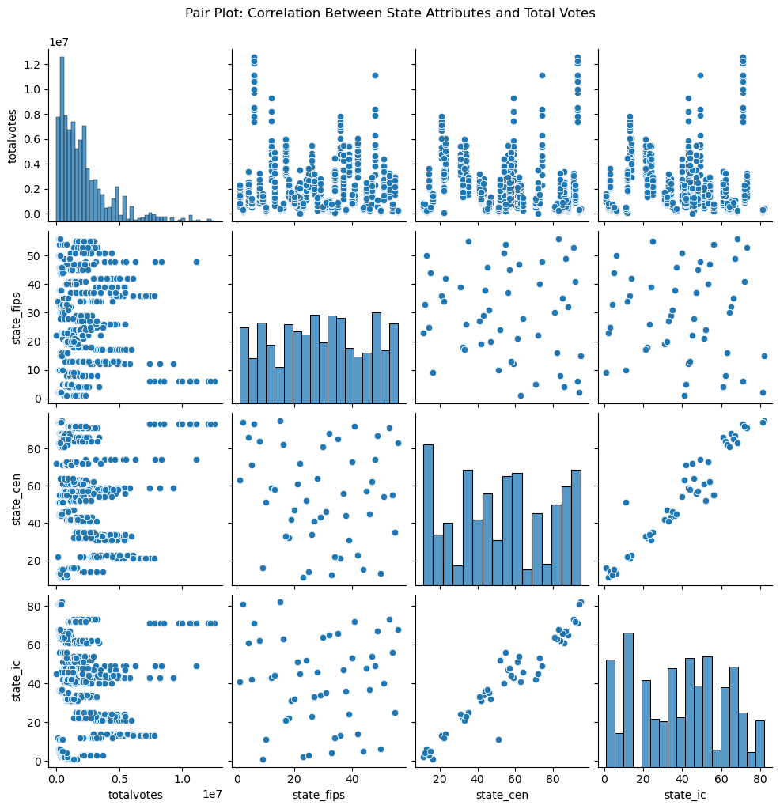

```python
# Import seaborn and matplotlib for plotting
import seaborn as sns
import matplotlib.pyplot as plt

# Select numerical variables of interest from the dataset
numeric_cols = ['totalvotes', 'state_fips', 'state_cen', 'state_ic']  # These are state-level attributes and vote totals

# Create pair plot to examine relationships and distributions
sns.pairplot(df_cleaned[numeric_cols])  # Pairwise scatter plots with histograms on the diagonal


plt.suptitle("Pair Plot: Correlation Between State Attributes and Total Votes", y=1.02)  # Adjust position of title
plt.savefig("pair_plot.png")
plt.show()  # Render the visual
```

### Question 2: Correlation Between State Attributes and Total Votes

The pair plot visualizes the relationship between total votes and state-level attributes such as `state_fips`, `state_cen`, and `state_ic`.

- **Distribution Patterns:** The diagonal histograms show the distribution of each variable. For instance, `totalvotes` is highly right-skewed, indicating a few states contribute disproportionately to the vote totals.
- **Correlation Observations:** While no strong linear correlation is visually obvious, there are some slight patterns suggesting weak negative or no relationship between the geographic identifiers (`state_fips`, `state_cen`, `state_ic`) and total votes.
- **Insight:** These identifiers likely serve more as categorical/geographical codes rather than explanatory variables, so their correlation with vote totals is expected to be weak.

This confirms that while these attributes help distinguish states, **they do not significantly predict voting volume**, which is instead more driven by **population and state size**.

## 5. Additional Analysis/Findings

#### Vote Trends Over Time by Party:

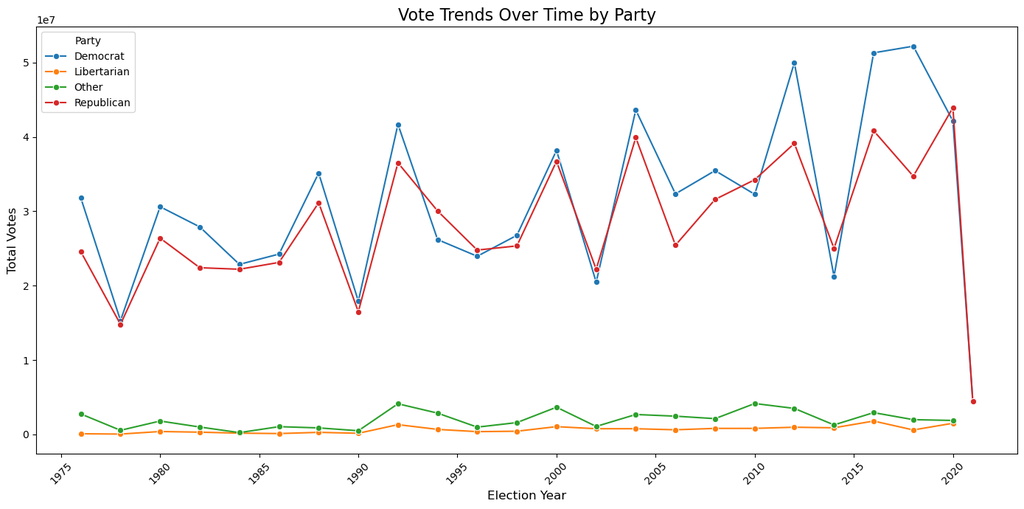

```python
valid_parties = ['Democrat', 'Republican', 'Libertarian', 'Other'] # Filter to include only major recognizable parties
filtered_df = df_cleaned[df_cleaned['party_simplified'].isin(valid_parties)]


party_votes = (               # Group by year and party, summing candidate votes
    filtered_df.groupby(['year', 'party_simplified'])['candidatevotes']
    .sum()
    .reset_index()
)


plt.figure(figsize=(14, 7)) # Set plot size and style
sns.lineplot(
    data=party_votes,
    x='year',
    y='candidatevotes',
    hue='party_simplified',
    marker='o'
)


plt.title('Vote Trends Over Time by Party', fontsize=16) # Add plot labels and title
plt.xlabel('Election Year', fontsize=12)
plt.ylabel('Total Votes', fontsize=12)
plt.legend(title='Party')
plt.xticks(rotation=45)
plt.tight_layout()
plt.savefig("party_vote_trends_over_time.png")


plt.show() # Show the plot
```

**Objective**

This line plot shows how total votes received by major political parties in U.S. Senate elections have changed over time.

**Conclusion:**

These findings emphasize the impact of state size, voter cycles, and party loyalty in shaping U.S. Senate election outcomes.

```python
# Save cleaned DataFrame to CSV
df_cleaned.to_csv("camille_settles_cleaned.csv", index=False)
```